# Human Activity Recognition

Alexander Alexandrov

## Overview

Using devices such as Jawbone Up, Nike FuelBand, and Fitbit it is now possible to collect a large amount of data about personal activity relatively inexpensively. These type of devices are part of the quantified self movement – a group of enthusiasts who take measurements about themselves regularly.

This project goal is to use data from accelerometers on the belt, forearm, arm, and dumbell of 6 participants to predict the manner in which they did the exercise.

The data for this project comes from this source: http://groupware.les.inf.puc-rio.br/har

## Exploratory Analysis

```r
# Load necessary packages
library(data.table)
library(dplyr)
library(caret)
library(ggplot2)
library(randomForest)
```

Read training data.

```r
# Data table is used due to performance purposes
setwd(".")
training <- fread("pml-training.csv")
str(training)
```

```
## Classes 'data.table' and 'data.frame':   19622 obs. of  160 variables:
##  $ V1                      : chr  "1" "2" "3" "4" ...
##  $ user_name               : chr  "carlitos" "carlitos" "carlitos" "carlitos" ...
##  $ raw_timestamp_part_1    : int  1323084231 1323084231 1323084231 1323084232 1323084232 1323084232 1323084232 1323084232 1323084232 1323084232 ...
##  $ raw_timestamp_part_2    : int  788290 808298 820366 120339 196328 304277 368296 440390 484323 484434 ...
##  $ cvtd_timestamp          : chr  "05/12/2011 11:23" "05/12/2011 11:23" "05/12/2011 11:23" "05/12/2011 11:23" ...
##  $ new_window              : chr  "no" "no" "no" "no" ...
##  $ num_window              : int  11 11 11 12 12 12 12 12 12 12 ...
##  $ roll_belt               : num  1.41 1.41 1.42 1.48 1.48 1.45 1.42 1.42 1.43 1.45 ...
##  $ pitch_belt              : num  8.07 8.07 8.07 8.05 8.07 8.06 8.09 8.13 8.16 8.17 ...
##  $ yaw_belt                : num  -94.4 -94.4 -94.4 -94.4 -94.4 -94.4 -94.4 -94.4 -94.4 -94.4 ...
##  $ total_accel_belt        : int  3 3 3 3 3 3 3 3 3 3 ...
##  $ kurtosis_roll_belt      : chr  "" "" "" "" ...
##  $ kurtosis_picth_belt     : chr  "" "" "" "" ...
##  $ kurtosis_yaw_belt       : chr  "" "" "" "" ...
```

[output cut: 87 more lines]

- Some of variables contain NAs or empty strings. Such variables should be considered for interpolation or should be removed from further analysis.
- Window can be used to aggregate and reduce training data.

The approach is simple. Start from simplified model on reduced data. Check accuracy. Move to more complicated model if necessary.

## Data Cleaning

Exclude columns with lots of NAs. Such columns can’t be interpolated so can’t be useful in machine learning.

```r
predictors.na.stat <- training[, colMeans(is.na(.SD) | .SD == "")]
# Less than 10% NAs
non.na.predictors <- names(training)[melt(predictors.na.stat) < 0.1]
```

Also predictors with nonrelevant information should be removed too. User name and timestapms can’t help to classify activity in common case.

```r
nonrelevant.predictors <- c("V1", "user_name", "raw_timestamp_part_1", "raw_timestamp_part_2", "cvtd_timestamp", "new_window")
relevant.predictors <- non.na.predictors[!(non.na.predictors %in% nonrelevant.predictors)]
relevant.training <- training[, relevant.predictors, with=FALSE]
```

## Further Exploratory Analysis

Just before averaging by window outliers should be considered.

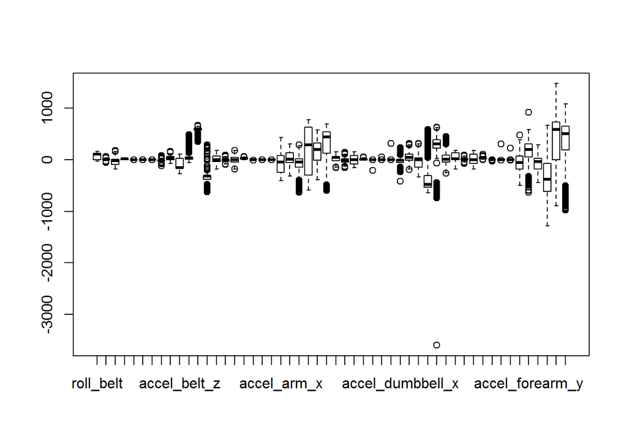

```r
boxplot(relevant.training[, -c("num_window", "classe"), with=FALSE])
```

According to this plot a lot of predictors contains ourliers (black circles). For example *Box-Cox* can be used to reduce outliers influence.

## Final Data Cleaning

Average measurements by window to reduce original data set.

```r
cleaned.training <- relevant.training[, lapply(.SD, mean), by=c("num_window", "classe")]
# Exclude window variable
cleaned.training <- cleaned.training[, -"num_window", with=FALSE]
```

## Data Preprocessing

Exclude covariate predictors by means of correlation matrix

```r
cleaned.measurements <- cleaned.training[, -"classe", with=FALSE]
predictors.cor <- abs(cor(cleaned.measurements))
predictors.cor[upper.tri(predictors.cor, diag=TRUE)] <- 0

# Correlation threshold is 0.8
predictors.cor.coords <- which(predictors.cor > 0.8, arr.ind=TRUE)
predictors.cor.coords.x <- unique(predictors.cor.coords[, "col"])
predictors.cor.coords.y <- unique(predictors.cor.coords[, "row"])

covariate.predictors.indices <- if (length(predictors.cor.coords.x) > length(predictors.cor.coords.y)) {
  predictors.cor.coords.x
} else {
  predictors.cor.coords.y
}

covariate.predictors <- names(cleaned.measurements)[covariate.predictors.indices]

reduced.training <- cleaned.training[, -covariate.predictors, with=FALSE]
```

## Random Forest

This method is simple enough to get started and powerful to fit nonlinear case.

```r
set.seed(1234)
rf.model.fit <- train(classe ~ ., data=reduced.training, method="rf", ntree=50, trainControl="cv", number=25, preProcess="BoxCox")
rf.model.fit
```

```
## Random Forest
##
## 858 samples
##  37 predictor
##   5 classes: 'A', 'B', 'C', 'D', 'E'
##
## Pre-processing: Box-Cox transformation (4)
## Resampling: Bootstrapped (25 reps)
## Summary of sample sizes: 858, 858, 858, 858, 858, 858, ...
## Resampling results across tuning parameters:
##
##   mtry  Accuracy   Kappa      Accuracy SD  Kappa SD
##    2    0.8402007  0.7973712  0.01411196   0.01781284
##   19    0.8356789  0.7916735  0.01922636   0.02427836
##   37    0.8206720  0.7725927  0.02667905   0.03368141
##
## Accuracy was used to select the optimal model using  the largest value.
## The final value used for the model was mtry = 2.
```

## Conclusion

The accuracy is greater than *0.8*. So this model works practically fine. To avoid overfitting this model can be choosen as final.

## Testing

```r
testing <- fread("pml-testing.csv")
predicted <- predict(rf.model.fit, newdata=testing)
cbind(testing[, c("user_name", "cvtd_timestamp"), with=FALSE],
      data.frame(classe=predicted))
```

```
##     user_name   cvtd_timestamp classe
##  1:     pedro 05/12/2011 14:23      C
##  2:    jeremy 30/11/2011 17:11      A
##  3:    jeremy 30/11/2011 17:11      A
##  4:    adelmo 02/12/2011 13:33      A
##  5:    eurico 28/11/2011 14:13      A
##  6:    jeremy 30/11/2011 17:12      E
##  7:    jeremy 30/11/2011 17:12      D
##  8:    jeremy 30/11/2011 17:11      B
##  9:  carlitos 05/12/2011 11:24      A
## 10:   charles 02/12/2011 14:57      A
## 11:  carlitos 05/12/2011 11:24      C
## 12:    jeremy 30/11/2011 17:11      C
## 13:    eurico 28/11/2011 14:14      B
## 14:    jeremy 30/11/2011 17:10      A
## 15:    jeremy 30/11/2011 17:12      E
## 16:    eurico 28/11/2011 14:15      E
## 17:     pedro 05/12/2011 14:22      A
## 18:  carlitos 05/12/2011 11:24      B
## 19:     pedro 05/12/2011 14:23      B
## 20:    eurico 28/11/2011 14:14      B
```